# Sup meeting 5

Anna Hutchinson

01/11/2018

## Model low, medium and high disorder systems

Model posterior probability systems were produced for low, medium and high disorder systems.

### Low power system (maf=0.05, OR=1, N0=N1=50)

```r
# x.low <- ref(maf=0.05)
# test.low <- simdata_x(x.low, OR=1, N0=50, N1=50) # get 100 systems
# t.low <- test.low[[1]][order(-test.low[[1]]$PP),]

setwd("/Users/anna/PhD")
t.low <- read.table("t.low")
head(t.low)
```

```
##        snp      pvalues   MAF         PP    CV
## s65 SNP.65 0.0005938498 0.055 0.01647548 FALSE
## s58 SNP.58 0.0013229541 0.043 0.01413227 FALSE
## s1   SNP.1 0.0231507202 0.060 0.01223052 FALSE
## s7   SNP.7 0.0362587474 0.062 0.01181555 FALSE
## s91 SNP.91 0.0389514797 0.057 0.01160966 FALSE
## s33 SNP.33 0.0425323171 0.053 0.01142506 FALSE
```

The plots below show the pdf and the cdf of the posterior probabilities for this low power system.

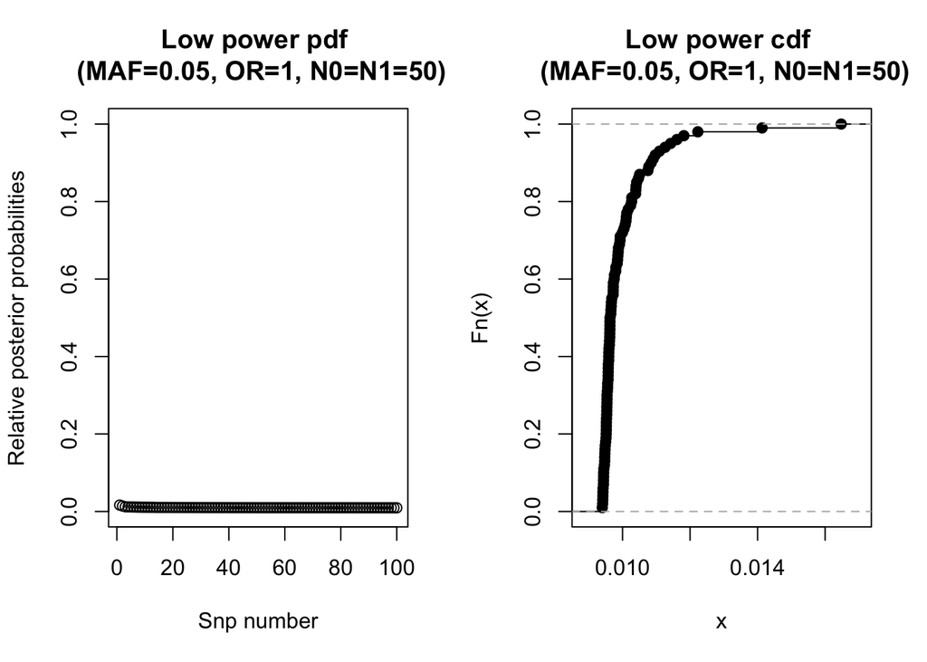

### Medium power system (maf=0.3, OR=1.1, N0=N1=700)

```r
# x.med <- ref(maf=0.3)
# test.med <- simdata_x(x.med, OR=1.1, N0=700, N1=700) # get 100 systems
# t.med <- test.med[[1]][order(-test.med[[1]]$PP),]

setwd("/Users/anna/PhD")
t.med <- read.table("t.med")
head(t.med)
```

```
##        snp    pvalues   MAF         PP    CV
## s27 SNP.27 0.01129078 0.294 0.08274654 FALSE
## s76 SNP.76 0.01650056 0.309 0.06204450 FALSE
## s64 SNP.64 0.01858309 0.279 0.05701422 FALSE
## s68 SNP.68 0.04594892 0.300 0.02921609 FALSE
## s42 SNP.42 0.06025226 0.302 0.02405483 FALSE
## s14 SNP.14 0.07338729 0.298 0.02097193 FALSE
```

The plots below show the pdf and the cdf of the posterior probabilities for this medium power system.

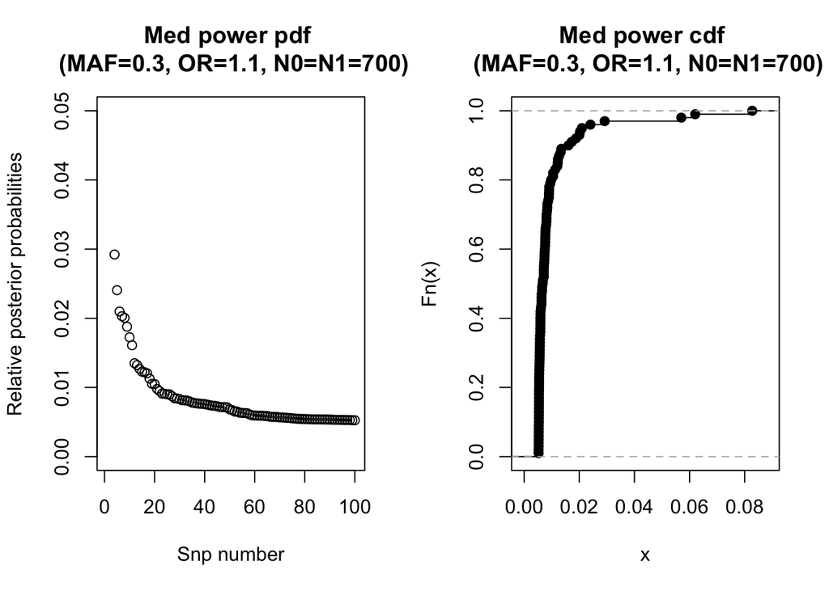

### High power system (maf=0.5, OR=1.3, N0=N1=1000)

```r
# x.high <- ref(maf=0.5)
# test.high <- simdata_x(x.high, OR=1.3, N0=1000, N1=1000) # get 100 systems
# t.high <- test.high[[1]][order(-test.high[[1]]$PP),]

setwd("/Users/anna/PhD")
t.high <- read.table("t.high")
head(t.high)
```

```
##        snp      pvalues   MAF           PP    CV
## s56 SNP.56 2.394407e-06 0.514 0.9841670039  TRUE
## s70 SNP.70 1.163447e-03 0.489 0.0048218359 FALSE
## s55 SNP.55 1.948468e-03 0.497 0.0031308545 FALSE
## s87 SNP.87 2.212163e-02 0.495 0.0004312507 FALSE
## s57 SNP.57 3.626935e-02 0.501 0.0002927989 FALSE
## s72 SNP.72 3.815923e-02 0.498 0.0002815128 FALSE
```

The plots below show the pdf and the cdf of the posterior probabilities for this high power system.

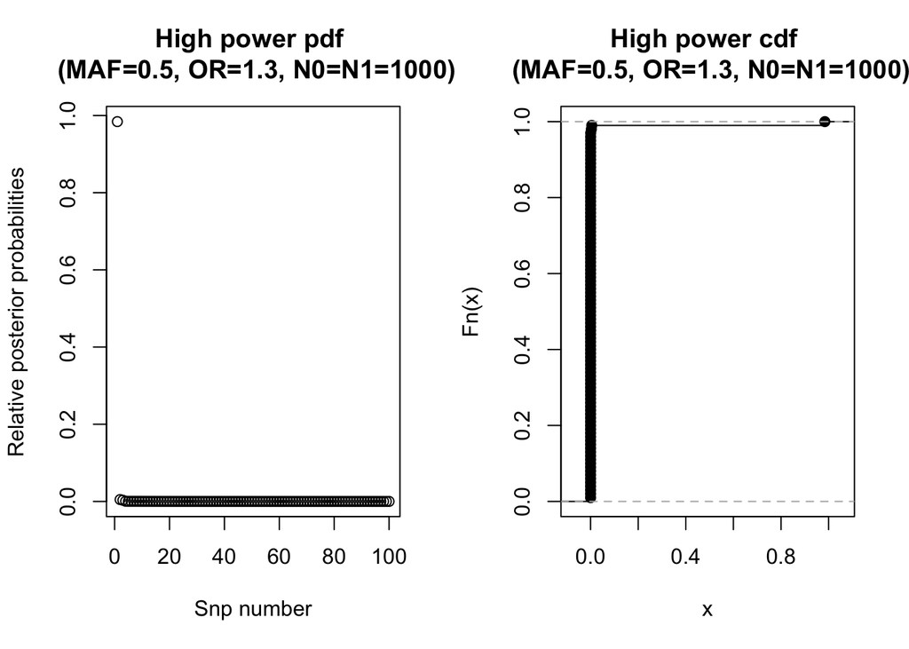

The following plot shows all three model systems on the same plot. Note the scale on the y axis, meaning we cannot see the first snp in the high power system (with probability 0.984).

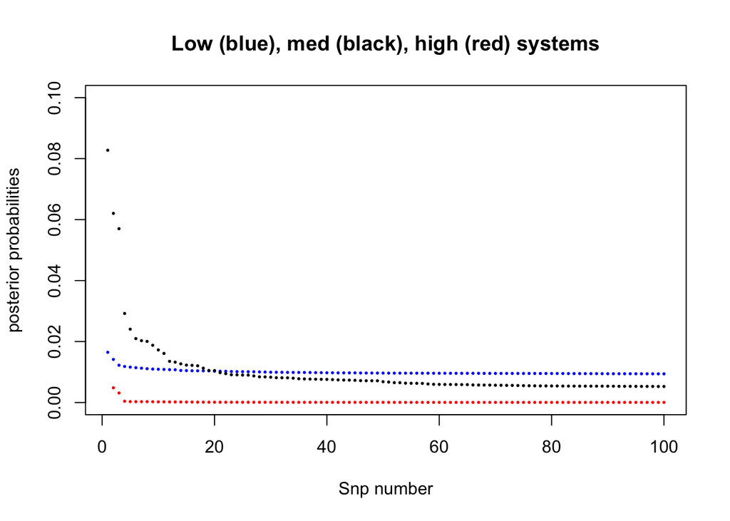

## Measures of entropy

Five different measures were considered to try and capture the disorder of the system.

1. ‘Entropy’: $-mean(log(pp))$
2. ‘Max’: $max(pp)$
3. ‘Median’: $median(pp)$
4. ‘AUCDF’: Area under the cdf
5. ‘KL divergence’: $\sum(pp*log(pp/q))$ where `q=rep(1/nsnps,nsnps)`.

The table below shows the values for these measures for the model systems above.

```r
# entropy
entropy(t.low$PP)
entropy(t.med$PP)
entropy(t.high$PP)

# max
max(t.low$PP)
max(t.med$PP)
max(t.high$PP)

# median
median(t.low$PP)
median(t.med$PP)
median(t.high$PP)

# AUCDF
AUCDF.low <- integrate(ecdf(t.low$PP), min(t.low$PP), max(t.low$PP))$value
AUCDF.med <- integrate(ecdf(t.med$PP), min(t.med$PP), max(t.med$PP))$value
AUCDF.high <- integrate(ecdf(t.high$PP), min(t.high$PP), max(t.high$PP))$value

# KL
q=rep(1/nsnps,nsnps)
nsnps=100
KL.low <- sum(t.low$PP*log(t.low$PP/q))
KL.med <- sum(t.med$PP*log(t.med$PP/q))
KL.high <- sum(t.high$PP*log(t.high$PP/q))
```

[output not shown]

#### Plot these results (low, medium then high)

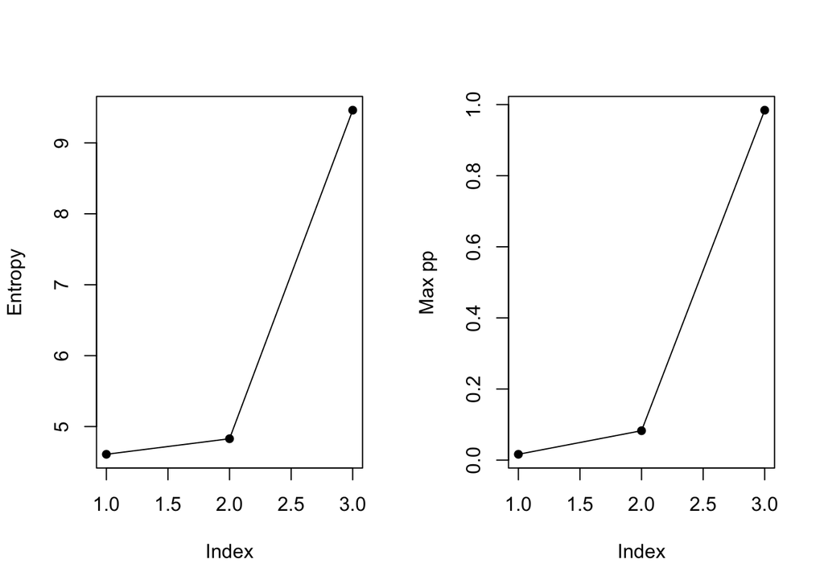

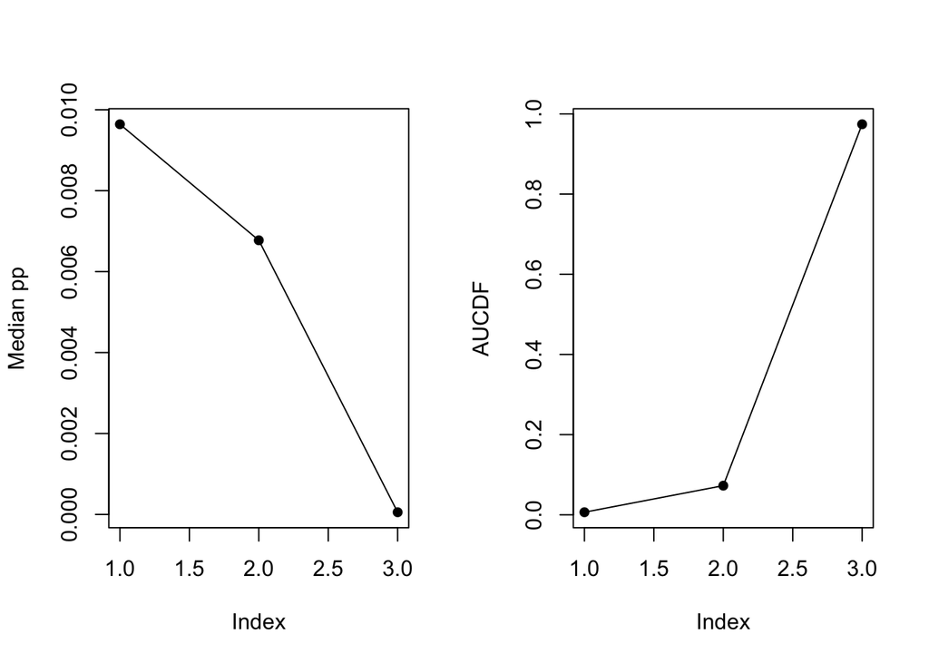

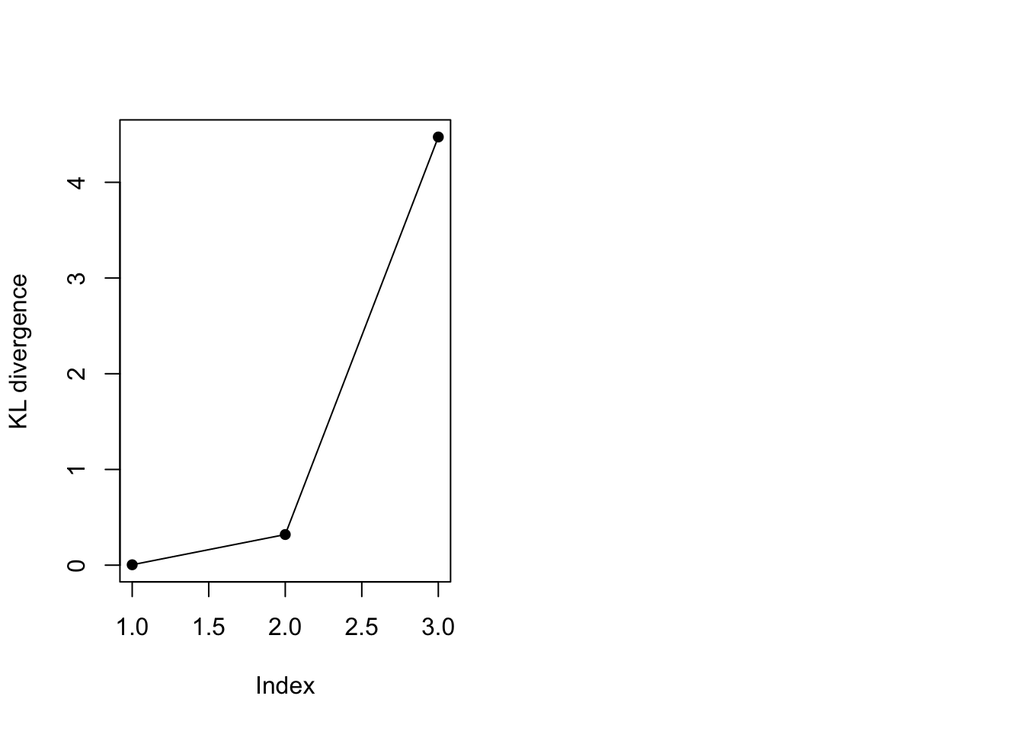

It seems that median(pp) may be a good distinguisher.

### Weighted exponential curves

```r
set.seed(2)
we <- rep(1,100)
we[1] <- 100 # set weight of first snp to 100
snps <- seq(1,100,1)

# fit exp model: low
exp.low <- lm(log(t.low$PP)~snps, weights=we)
pred <- exp(predict(exp.low,list=(snps),type="response"))

# fit exp model: med
exp.med <- lm(log(t.med$PP)~snps, weights=we)
pred.med <- exp(predict(exp.med,list=(snps),type="response"))

# fit exp model: high
exp.high <- lm(log(t.high$PP)~snps, weights = we)
pred.high <- exp(predict(exp.high,list=(snps),type="response"))
```

The plot below shows the points and the fitted exponential curves.

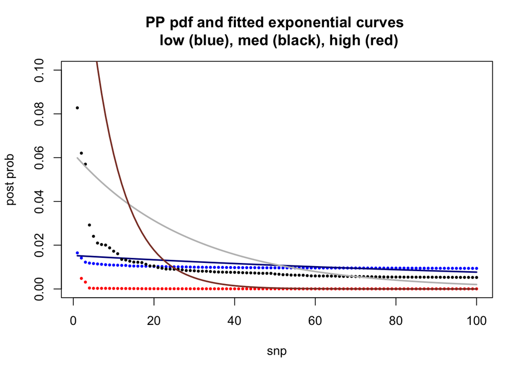

The equations are given below:

Low:

$pp = 0.01529\times exp(-0.0069x)$

Medium:

$pp = 0.06196\times exp(-0.0342x)$

High:

$pp = 0.21383\times exp(-0.1244x)$

In order to quantify the difference in the fitted exponential curves, I consider the slope coefficient. This represents how many times it’s own height the slope is. For example, for the high disorder system, the curves slope is -0.1244 times its own height.

```r
slope.low <- exp.low$coefficients[[2]]
slope.med <- exp.med$coefficients[[2]]
slope.high <- exp.high$coefficients[[2]]
```

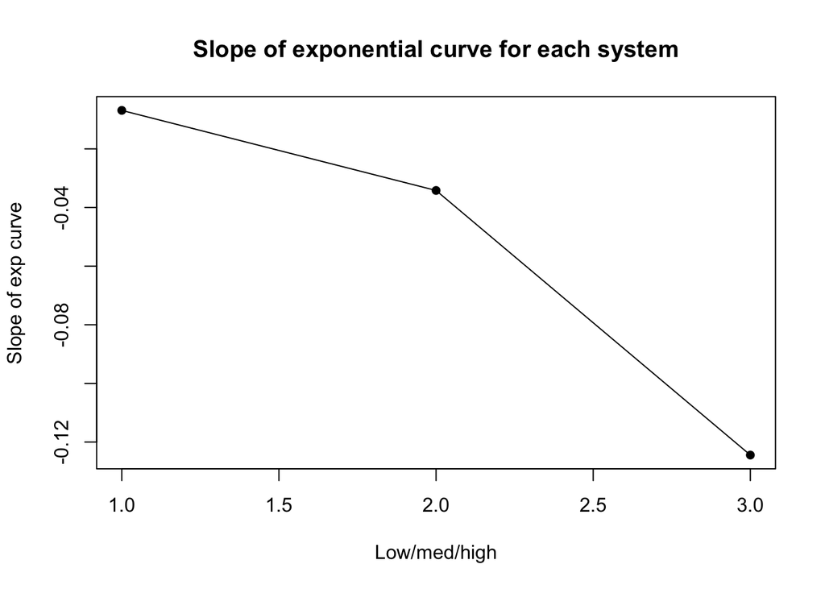

A new simulation dataset (20000 entries) was made with fixed nsnps = 100, maf=0.5, LD1=0.3, LD2=0.2. In the `wrapper2_x` function, I have changed possible sample sizes from 1000-5000 to 100-500, in order to achieve systems with less power (less instances of 1 snp taking all the probability).

```r
set.seed(2)
wrapper2_x <- function(x) {
  n <- sample(1:5,1)*100 # vary sample size
  or <- sample(c(1,1.05,1.08,1.1,1.15,1.2),1) # vary or
  thr <- sample(c(0.5,0.6,0.7,0.8,0.9),1) # vary threshold
  data <- simdata_x(x,N0=n,N1=n,OR=or) #,...) # data is a list of data.frames

  cs <- lapply(data, function(d) {
    tmp.ord <- credset(d$PP, which(d$CV), thr=thr)
    tmp.noord <- credset(d$PP, which(d$CV), do.order=FALSE,thr=thr)
    data.frame(order=c(TRUE,FALSE),
               thr=tmp.ord$thr,
               size=c(tmp.ord$size,tmp.noord$size),
               nvar=c(length(tmp.ord$credset),
                      length(tmp.noord$credset)),
               covered=c(tmp.ord$contained,
                         tmp.noord$contained))
  })
  q <- rep(1/100,100)
  cs <- do.call("rbind",cs)
  ent <- sapply(data, function(x) entropy(x$PP))
  max_pp <- sapply(data, function(x) max_pp(x$PP))
  KL <- sapply(data, function(x) KL(x$PP))
  AUCDF <- sapply(data, function(x) AUCDF(x$PP))
  slope <- sapply(data, function(x) slope(x$PP))
  cs$entropy <- rep(ent,each=2)
  cs$max_pp <- rep(max_pp,each=2)
  cs$KL <- rep(KL, each=2)
  cs$AUCDF <- rep(AUCDF, each=2)
  cs$slope <- rep(slope, each=2)
  cs$N <- n
  cs$OR <- or
  cs$thr <- thr
  cs
}

entropy <- function(p) -mean(log(p))
max_pp <- function(p) max(p)
KL <- function(p) sum(p*log(p/q))
AUCDF <- function(p) integrate(ecdf(p), min(p), max(p))$value
slope <- function(p){
  model <- lm(log(p)~snps, weights=we)
  slope <- model$coefficients[[2]]
  print(slope)
}

### simulation
# x <- ref(LD1=0.3,LD2=0.2)
# new <- replicate(100,wrapper2_x(x), simplify=FALSE)
# new <- data.table::rbindlist(new)
setwd("/Users/anna/PhD")
new <- read.table("newsup5")
new <- as.data.table(new)
new$size[new$size > 0.999999] <- 0.999999
new$size <- log(new$size/(1-new$size))
colnames(new)[3] <- "logitsize"
new$covered <- as.numeric(new$covered)
new.ord <- new[order==TRUE,]
new.noord <- new[order=="FALSE",]
new.ord <- new.ord[,-1] # remove order column
new.noord <- new.noord[,-1]
head(new.ord)
```

```
##    thr logitsize nvar covered  entropy     max_pp        KL      AUCDF
## 1: 0.9  2.251791   84       0 4.773563 0.09821850 0.2498108 0.08827002
## 2: 0.9  2.222214   84       1 4.757642 0.06160455 0.1983759 0.05160857
## 3: 0.9  2.225780   85       1 4.741005 0.08126536 0.1973815 0.07126768
## 4: 0.9  2.217167   81       1 4.913480 0.22261730 0.6031253 0.21261691
## 5: 0.9  2.248865   80       1 5.024976 0.27797163 0.8496647 0.26793930
## 6: 0.9  2.254408   84       0 4.756994 0.07366871 0.2095674 0.06367533
##           slope   N   OR
## 1:  0.001724957 300 1.08
## 2: -0.007755567 300 1.08
## 3:  0.002238072 300 1.08
## 4: -0.020581325 300 1.08
## 5: -0.001754392 300 1.08
## 6:  0.002278427 300 1.08
```

```r
head(new.noord)
```

```
##    thr logitsize nvar covered  entropy     max_pp        KL      AUCDF
## 1: 0.9  2.243726   87       1 4.773563 0.09821850 0.2498108 0.08827002
## 2: 0.9  2.356950   89       1 4.757642 0.06160455 0.1983759 0.05160857
## 3: 0.9  2.285329   89       1 4.741005 0.08126536 0.1973815 0.07126768
## 4: 0.9  2.240892   92       1 4.913480 0.22261730 0.6031253 0.21261691
## 5: 0.9  2.197311   81       1 5.024976 0.27797163 0.8496647 0.26793930
## 6: 0.9  2.288564   88       1 4.756994 0.07366871 0.2095674 0.06367533
##           slope   N   OR
## 1:  0.001724957 300 1.08
## 2: -0.007755567 300 1.08
## 3:  0.002238072 300 1.08
## 4: -0.020581325 300 1.08
## 5: -0.001754392 300 1.08
## 6:  0.002278427 300 1.08
```